# STSCI 5065 - Homework 3

Harry Lu

dl947

# Problem Set 1

[70 pts] You are given a set of two text files of New York Stock Exchange (NYSE) data, **`NYSE_daily_prices.csv`** and **`NYSE_dividends.csv`**. You are required to create a Hive database containing two tables based on the text files, and then do some analysis of the data using Hive queries.

## A

[6 pts] Download the data file, stock.zip, from the course website and unzip it in a local OS directory. Open the files in a text editor to see how the data fields are separated. Create an HDFS directory, **HW3**, right below the CentOS root. In HW3, create a directory called **stockdata**. Use the File View in Ambari to upload the two data files into stockdata. Display a screenshot (in Ambari) showing all these files in the /HW3/stockdata directory (your screenshot should show this directory).

```
[root@sandbox ~]# hadoop fs -mkdir /HW3
[root@sandbox ~]# hadoop fs -mkdir /HW3/stockdata
```

[figure not shown]

## B

[13 pts] Create a Hive database called **stocksdb** located in HW3. In the stocksdb database, use Hive command line interface to create two tables **stock_prices** and **stock_dividends**. The **stock_prices** table contains columns in the following order: **`exchng`**, **`symbol`**, **`ymd`**, **`price_open`**, **`price_high`**, **`price_low`**, **`price_close`**, **`price_volume`**, and **`price_adj_close`**. The data types of **`exchng`**, **`symbol`** and **`ymd`** are **`STRING`** (same in the **stock_dividends** table) and other columns are of the **`DOUBLE`** data type. The **stock_dividends** contains the columns in the following order: **`exchng`**, **`symbol`**, **`ymd`**, and **`dividend`**. The data type of **`dividend`** is **`DOUBLE`**. Describe these two tables in Hive command line interface, and attach one single screenshot, showing the commands and the results.

```
[root@sandbox ~]# hive

Logging initialized using configuration in file:/etc/hive/2.5.0.0-1245/0/hive-log4j.properties
```

```
hive> CREATE DATABASE stocksdb
    > LOCATION '/HW3';
OK
Time taken: 0.059 seconds
```

```
hive> DESCRIBE DATABASE stocksdb;
OK
stocksdb                hdfs://sandbox.hortonworks.com:8020/HW3 root    USER
Time taken: 0.309 seconds, Fetched: 1 row(s)
```

```
hive> CREATE TABLE stocksdb.stock_prices (
    >   exchng STRING,
    >   symbol STRING,
    >   ymd STRING,
    >   price_open DOUBLE,
    >   price_high DOUBLE,
    >   price_low DOUBLE,
    >   price_close DOUBLE,
    >   price_volumn DOUBLE,
    >   price_adj_close DOUBLE
    > )
    > ROW FORMAT DELIMITED
    >   FIELDS TERMINATED BY ',';
OK
Time taken: 0.868 seconds
```

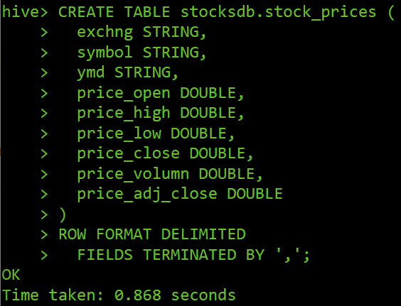

```
hive> CREATE TABLE stocksdb.stock_dividends (
    >   exchng STRING,
    >   symbol STRING,
    >   ymd STRING,
    >   dividend DOUBLE
    > )
    > ROW FORMAT DELIMITED
    >   FIELDS TERMINATED BY ',';
OK
Time taken: 0.885 seconds
```

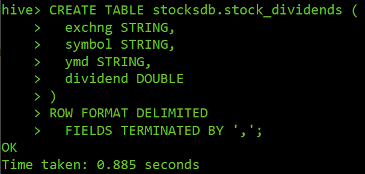

```
hive> DESCRIBE stocksdb.stock_prices;
OK
exchng                  string
symbol                  string
ymd                     string
price_open              double
price_high              double
price_low               double
price_close             double
price_volumn            double
price_adj_close         double
Time taken: 0.655 seconds, Fetched: 9 row(s)
```

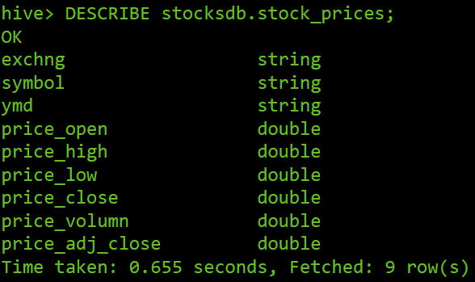

```
hive> DESCRIBE stocksdb.stock_dividends;
OK
exchng                  string
symbol                  string
ymd                     string
dividend                double
Time taken: 0.602 seconds, Fetched: 4 row(s)
```

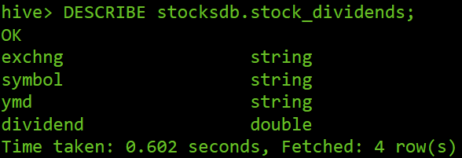

## C

[5 pts] Load the data files into the respective tables created in step B.

```
hive> LOAD DATA INPATH '/HW3/stockdata/NYSE_daily_prices.csv'
    > OVERWRITE INTO TABLE stocksdb.stock_prices;
Loading data to table stocksdb.stock_prices
chmod: changing permissions of 'hdfs://sandbox.hortonworks.com:8020/HW3/stock_prices/NYSE_daily_prices.csv': Permission denied. user=root is not the owner of inode=NYSE_daily_prices.csv
Table stocksdb.stock_prices stats: [numFiles=1, numRows=0, totalSize=32034630, rawDataSize=0]
OK
Time taken: 1.044 seconds
```

```
hive> LOAD DATA INPATH '/HW3/stockdata/NYSE_dividends.csv'
    > OVERWRITE INTO TABLE stocksdb.stock_dividends;
Loading data to table stocksdb.stock_dividends
chmod: changing permissions of 'hdfs://sandbox.hortonworks.com:8020/HW3/stock_dividends/NYSE_dividends.csv': Permission denied. user=root is not the owner of inode=NYSE_dividends.csv
Table stocksdb.stock_dividends stats: [numFiles=1, numRows=0, totalSize=229907, rawDataSize=0]
OK
Time taken: 1.512 seconds
```

## D

[6 pts] Query the **stock_prices** table to find out the number of entries of each stock symbol. You are only required to show two screenshots of the first 10 rows and the last 10 rows of your result, including the line starting with “Time taken” in your output.

```r
prices %>% count(prices$V2)
```

```
## # A tibble: 168 x 2
##    `prices$V2`     n
##    <fct>       <int>
##  1 BA          12109
##  2 BAC          5977
##  3 BAF          1830
##  4 BAK          2785
##  5 BAM          6495
##  6 BAP          3539
##  7 BAS          1047
##  8 BAX          7115
##  9 BBD          1891
## 10 BBF          2142
## # ... with 158 more rows
```

```
hive> SELECT symbol, count(*) FROM stocksdb.stock_prices GROUP BY symbol;
Query ID = root_20190330000504_6c370cc5-e1cd-4938-ba88-8a3750267310
Launching Job 1 out of 1


Status: Running (Executing on YARN cluster with App id application_1553903681705_0001)

--------------------------------------------------------------------------------
        VERTICES      STATUS  TOTAL  COMPLETED  RUNNING  PENDING  FAILED  KILLED
--------------------------------------------------------------------------------
Map 1 ..........   SUCCEEDED      2          2        0        0       0       0
Reducer 2 ......   SUCCEEDED      1          1        0        0       0       0
--------------------------------------------------------------------------------
VERTICES: 02/02  [==========================>>] 100%  ELAPSED TIME: 11.89 s
--------------------------------------------------------------------------------
OK
BA      12109
BAC     5977
BAF     1830
BAK     2785
BAM     6495
BAP     3539
BAS     1047
BAX     7115
BBD     1891
BBF     2142
BBG     1299
BBI     2633
BBK     1959
BBL     1667
BBT     5003
BBV     5293
BBVA    5331
BBW     1326
BBX     3502
BBY     6257
BC      7091
BCA     1247
BCE     6406
BCF     847
```

[output cut: 130 more lines]

```
BWS     6405
BWY     670
BX      663
BXC     1295
BXG     5562
BXP     3175
BXS     6132
BYD     4103
BYI     6354
BYM     1830
BZ      658
BZA     1953
BZH     4018
BZMD    18
Time taken: 13.799 seconds, Fetched: 168 row(s)
```

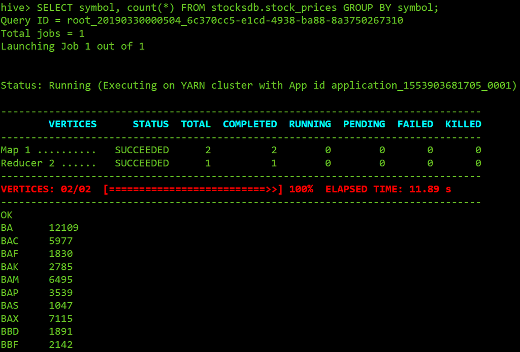

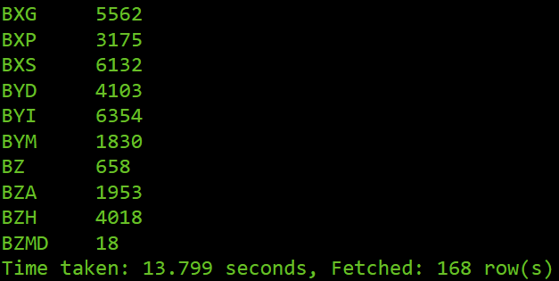

## E

[6 pts] Calculate the average stock opening price of each stock symbol rounded to 4 decimal points (same below). Use an alias, **ap**, for the average price column. Attach a screenshot of the last ten rows of the output.

```
hive> SELECT symbol, round(avg(price_open), 4) as ap FROM stocksdb.stock_prices GROUP BY symbol;
Query ID = root_20190330002553_06ec6b33-cfe8-4483-bad6-1888c4cb0b83
Total jobs = 1
Launching Job 1 out of 1


Status: Running (Executing on YARN cluster with App id application_1553903681705_0002)

--------------------------------------------------------------------------------
        VERTICES      STATUS  TOTAL  COMPLETED  RUNNING  PENDING  FAILED  KILLED
--------------------------------------------------------------------------------
Map 1 ..........   SUCCEEDED      2          2        0        0       1       0
Reducer 2 ......   SUCCEEDED      1          1        0        0       0       0
--------------------------------------------------------------------------------
VERTICES: 02/02  [==========================>>] 100%  ELAPSED TIME: 11.29 s
--------------------------------------------------------------------------------
OK
BA      49.48
BAC     49.9334
BAF     13.5553
BAK     14.7304
BAM     18.588
BAP     25.5388
BAS     19.7148
BAX     39.0276
BBD     27.8144
BBF     14.2571
BBG     33.4511
BBI     10.3553
BBK     15.064
BBL     38.8542
BBT     29.847
BBV     23.2844
BBVA    23.2422
BBW     18.1701
BBX     10.1855
BBY     34.9596
BC      24.1348
BCA     28.2903
BCE     25.7233
BCF     13.2207
BCH     37.2523
BCK     13.6995
BCO     33.11
BCR     42.7036
BCS     51.3602
BDC     23.3845
BDF     14.3834
BDJ     11.5774
BDK     35.4481
BDN     13.5993
BDT     12.2757
BDV     12.361
BDX     50.0056
BE      87.2495
BEC     41.1067
BEE     13.9113
BEN     49.1904
BEO     15.1297
BEP     15.7541
BEZ     22.1853
BFK     14.2055
BFO     13.4897
BFR     14.597
BFS     26.0
BFZ     14.1895
BG      53.7117
BGC     23.595
BGG     35.2899
BGH     22.0225
BGP     19.0761
BGR     25.6682
BGS     8.8154
BGT     15.9878
BGY     13.2689
BHD     13.1486
BHE     24.4158
BHI     33.4923
BHK     12.955
BHL     11.5993
BHP     33.9095
BHS     24.5067
BHY     9.3244
BID     17.4525
BIE     14.7324
BIF     6.4115
BIG     17.6989
BIN     13.8179
BIO     36.7844
BIP     15.4947
BJ      32.3333
BJS     32.3902
BJZ     14.6226
BK      33.9233
BKC     21.6195
BKD     28.3796
BKE     25.8886
BKH     23.7256
BKI     14.54
BKK     14.4667
BKN     12.995
BKS     30.2551
BKT     5.5766
BLC     4.9595
BLH     15.3089
BLK     97.0208
BLL     39.0545
BLT     10.0038
BLU     4.8717
BLW     17.0317
BLX     23.7798
BMA     22.8413
BMC     38.5282
BME     24.8317
BMI     26.8641
BMO     38.0507
BMR     21.8394
BMS     29.6025
BMT     9.3922
BMY     52.5522
BNA     9.0228
BNE     14.9177
BNI     55.7838
BNJ     15.1483
BNS     39.6225
BNY     14.6668
BOE     23.2013
BOH     34.5676
BP      62.948
BPI     15.4587
BPK     15.2434
BPL     28.8718
BPO     21.8529
BPP     20.3766
BPT     28.7897
BPZ     6.541
BQH     14.9073
BQR     13.4323
BR      18.8518
BRC     29.9132
BRE     25.4864
BRF     38.9268
BRFS    37.8637
BRO     29.6084
BRS     21.0683
BRT     10.6905
BRY     20.1571
BSBR    13.1079
BSC     8.3833
BSD     14.3101
BSE     13.7487
BSI     12.023
BSP     11.8786
BSX     29.0502
BSY     49.9165
BT      58.8239
BTA     11.619
BTE     20.3052
BTF     14.0928
BTH     28.1526
BTM     17.1641
BTO     9.8352
BTU     45.1322
BTZ     14.6474
BUD     46.4123
BVF     28.3709
BVN     24.608
BW      18.8464
BWA     46.6427
BWF     24.0277
BWP     26.3011
BWS     20.1872
BWY     11.7925
BX      15.5017
BXC     8.2128
BXG     5.3577
BXP     55.4753
BXS     23.523
BYD     17.449
BYI     11.3204
BYM     13.8966
BZ      4.6387
BZA     14.7472
BZH     37.9346
BZMD    24.5267
Time taken: 12.028 seconds, Fetched: 168 row(s)
```

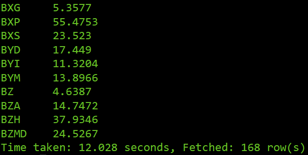

## F

[3 pts] Create a Hive view, **average_price_v**, based on step E.

```
hive> CREATE VIEW stocksdb.average_price_v AS
    >   SELECT symbol, round(avg(price_open), 4) as ap FROM stocksdb.stock_prices GROUP BY symbol;
OK
Time taken: 2.179 seconds
```

## G

[12 pts] Find out the stock symbols that have the highest and lowest average opening prices, respectively. You are required to use the view created in step F and to complete this query in Ambari using the Hive View. Attach the screenshots of the query results.

Min:

```
SELECT symbol, ap FROM stocksdb.average_price_v SORT BY ap LIMIT 1;
```

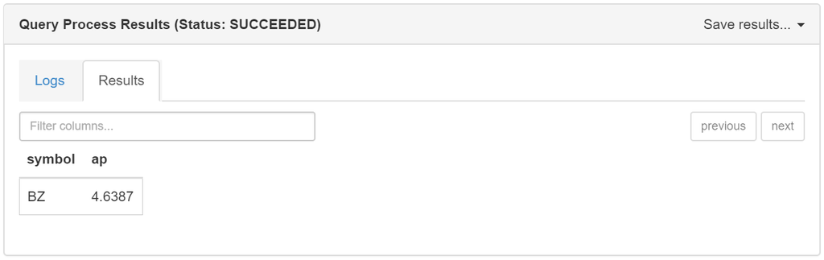

```
hive> SELECT symbol, ap FROM stocksdb.average_price_v SORT BY ap LIMIT 1;
Query ID = root_20190330010316_ea752c8b-d87c-40fb-ae19-b3c609bd47b7
Total jobs = 1
Launching Job 1 out of 1


Status: Running (Executing on YARN cluster with App id application_1553903681705_0003)

--------------------------------------------------------------------------------
        VERTICES      STATUS  TOTAL  COMPLETED  RUNNING  PENDING  FAILED  KILLED
--------------------------------------------------------------------------------
Map 1 ..........   SUCCEEDED      2          2        0        0       0       0
Reducer 2 ......   SUCCEEDED      1          1        0        0       0       0
Reducer 3 ......   SUCCEEDED      1          1        0        0       0       0
Reducer 4 ......   SUCCEEDED      1          1        0        0       0       0
--------------------------------------------------------------------------------
VERTICES: 04/04  [==========================>>] 100%  ELAPSED TIME: 16.07 s
--------------------------------------------------------------------------------
OK
BZ      4.6387
Time taken: 17.494 seconds, Fetched: 1 row(s)
```

MAX:

```
SELECT symbol, ap FROM stocksdb.average_price_v SORT BY ap DESC LIMIT 1;
```

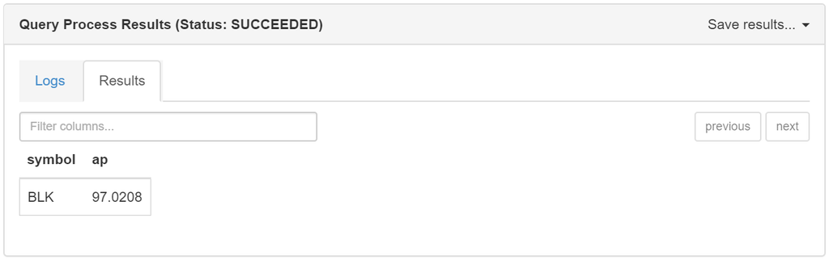

```
hive> SELECT symbol, ap FROM stocksdb.average_price_v SORT BY ap DESC LIMIT 1;
Query ID = root_20190330010528_96e42f26-2b24-4863-81d9-e331e2c4810d
Total jobs = 1
Launching Job 1 out of 1


Status: Running (Executing on YARN cluster with App id application_1553903681705_0003)

--------------------------------------------------------------------------------
        VERTICES      STATUS  TOTAL  COMPLETED  RUNNING  PENDING  FAILED  KILLED
--------------------------------------------------------------------------------
Map 1 ..........   SUCCEEDED      2          2        0        0       0       0
Reducer 2 ......   SUCCEEDED      1          1        0        0       0       0
Reducer 3 ......   SUCCEEDED      1          1        0        0       0       0
Reducer 4 ......   SUCCEEDED      1          1        0        0       0       0
--------------------------------------------------------------------------------
VERTICES: 04/04  [==========================>>] 100%  ELAPSED TIME: 16.52 s
--------------------------------------------------------------------------------
OK
BLK     97.0208
Time taken: 18.806 seconds, Fetched: 1 row(s)
```

## H

[12 pts] Find out the stock symbol that has the highest dividends. What are the date and the opening price of that stock when that happened? Complete this query also in Ambari’s Hive View. Attach the screenshots of the query results.

```
hive> SELECT stock_dividends.symbol, stock_dividends.ymd, price_open, dividend
    >   FROM stocksdb.stock_dividends, stocksdb.stock_prices
    >   WHERE stock_dividends.symbol = stock_prices.symbol
    >   SORT BY dividend DESC
    >   LIMIT 1;
Query ID = root_20190330012755_2eded503-20c9-47ef-a1e1-b019f7e2eee2
Total jobs = 1
Launching Job 1 out of 1


Status: Running (Executing on YARN cluster with App id application_1553903681705_0007)

--------------------------------------------------------------------------------
        VERTICES      STATUS  TOTAL  COMPLETED  RUNNING  PENDING  FAILED  KILLED
--------------------------------------------------------------------------------
Map 1 ..........   SUCCEEDED      1          1        0        0       0       0
Map 2 ..........   SUCCEEDED      2          2        0        0       0       0
Reducer 3 ......   SUCCEEDED      1          1        0        0       0       0
Reducer 4 ......   SUCCEEDED      1          1        0        0       0       0
--------------------------------------------------------------------------------
VERTICES: 04/04  [==========================>>] 100%  ELAPSED TIME: 33.21 s
--------------------------------------------------------------------------------
OK
BCE     2000-05-09      26.81   87.057999
Time taken: 34.215 seconds, Fetched: 1 row(s)
```

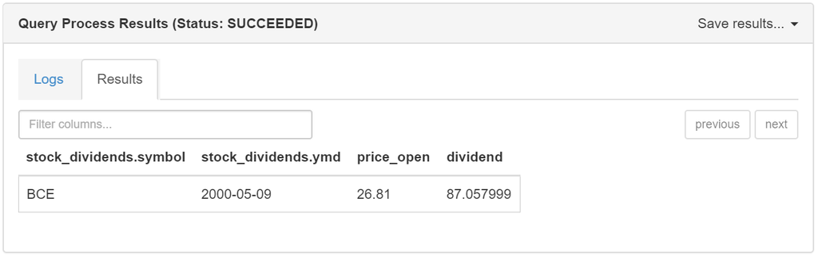

# Problem Set 2

[30 pts] You are given a text file (**`flight12.csv`**) of flight delays and are required to create a Hive table using regular expressions, and then do some queries on the table.

## A

[5 pts] Download the data file and use the File View in Ambari to load the file into HDFS in the HW3 directory. Create a Hive database called **flightsdb** located in HW3, and then in **flightsdb** create a Hive table, **flight_delays_hw3**. This table has the following columns: **`ymd`**, **`flight_num`**, **`carrier_delay`**, **`weather_delay`**, **`nas_delay`**, **`security_delay`**, and **`late_aircraft_delay`**. The first two columns are of the **`STRING`** data type and the other columns are of the **`DOUBLE`** data type.

```
hive> CREATE DATABASE flightsdb
    > LOCATION '/HW3';
OK
Time taken: 0.233 seconds
```

```
hive> CREATE TABLE flightsdb.flight_delays_hw3 (
    >   ymd STRING,
    >   flight_num STRING,
    >   carrier_delay DOUBLE,
    >   weather_delay DOUBLE,
    >   nas_delay DOUBLE,
    >   security_delay DOUBLE,
    >   late_aircraft_delay DOUBLE
    > )
    > ROW FORMAT DELIMITED
    >  FIELDS TERMINATED BY ',';
OK
Time taken: 0.579 seconds
```

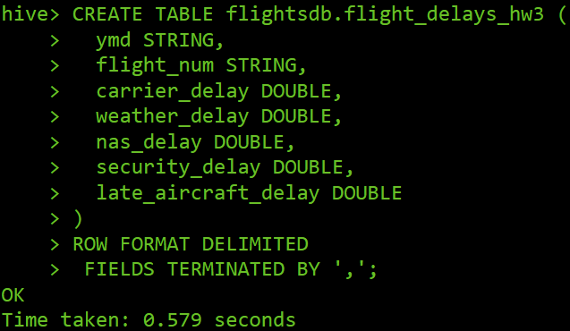

## B

[3 pts] Create a temporary one-column Hive table, **temp_flight**, to read in the data from the text file so that a line of text becomes a row in the **temp_flight** table, and then load the text data file into **temp_flight**.

```
hive> CREATE TABLE flightsdb.temp_flight (col_value STRING);
OK
Time taken: 0.355 seconds
```

```
hive> LOAD DATA INPATH '/HW3/flight12.csv'
    > OVERWRITE INTO TABLE flightsdb.temp_flight;
Loading data to table flightsdb.temp_flight
chmod: changing permissions of 'hdfs://sandbox.hortonworks.com:8020/HW3/temp_flight/flight12.csv': Permission denied. user=root is not the owner of inode=flight12.csv
Table flightsdb.temp_flight stats: [numFiles=1, numRows=0, totalSize=65827697, rawDataSize=0]
OK
Time taken: 0.958 seconds
```

## C

[15 pts] Insert data into **flight_delays_hw3** by extracting it from **temp_flight** with regular expression (`regexp_extract()`) calls. The data fields are separated by commas. You are required to extract fields 2, 5, 19, 20, 21, 22 and 23 to populate your table.

```
hive> INSERT OVERWRITE TABLE flightsdb.flight_delays_hw3
    > SELECT
    >   regexp_extract(col_value, '^(?:([^,]*)\,?){2}', 1) ymd,
    >   regexp_extract(col_value, '^(?:([^,]*)\,?){5}', 1) flight_num,
    >   regexp_extract(col_value, '^(?:([^,]*)\,?){19}', 1) carrier_delay,
    >   regexp_extract(col_value, '^(?:([^,]*)\,?){20}', 1) weather_delay,
    >   regexp_extract(col_value, '^(?:([^,]*)\,?){21}', 1) nas_delay,
    >   regexp_extract(col_value, '^(?:([^,]*)\,?){22}', 1) security_delay,
    >   regexp_extract(col_value, '^(?:([^,]*)\,?){23}', 1) late_aircraft_delay
    > FROM flightsdb.temp_flight;
Query ID = root_20190330022238_07aec438-f088-4912-aebc-a6cb676c24e6
Total jobs = 1
Launching Job 1 out of 1
Tez session was closed. Reopening...
Session re-established.


Status: Running (Executing on YARN cluster with App id application_1553903681705_0009)

--------------------------------------------------------------------------------
        VERTICES      STATUS  TOTAL  COMPLETED  RUNNING  PENDING  FAILED  KILLED
--------------------------------------------------------------------------------
Map 1 ..........   SUCCEEDED      4          4        0        0       0       0
--------------------------------------------------------------------------------
VERTICES: 01/01  [==========================>>] 100%  ELAPSED TIME: 46.32 s
--------------------------------------------------------------------------------
Loading data to table flightsdb.flight_delays_hw3
Table flightsdb.flight_delays_hw3 stats: [numFiles=4, numRows=516740, totalSize=17609868, rawDataSize=17093128]
OK
Time taken: 65.209 seconds
```

## D

[2 pts] Query the **flight_delays_hw3** table with Hive command line and by only display the first 10 rows. Attach a screenshot of Hive command line and its result.

```
ALTER TABLE flightsdb.flight_delays_hw3
    SET TBLPROPERTIES ("skip.header.line.count"="1");
```

```
hive> SELECT * FROM flightsdb.flight_delays_hw3 LIMIT 10;
OK
2013-12-01      "2900"  NULL    NULL    NULL    NULL    NULL
2013-12-02      "2900"  0.0     0.0     0.0     0.0     36.0
2013-12-03      "2900"  NULL    NULL    NULL    NULL    NULL
2013-12-04      "2900"  NULL    NULL    NULL    NULL    NULL
2013-12-05      "2900"  NULL    NULL    NULL    NULL    NULL
2013-12-06      "2900"  10.0    0.0     0.0     0.0     11.0
2013-12-07      "2900"  NULL    NULL    NULL    NULL    NULL
2013-12-08      "2900"  NULL    NULL    NULL    NULL    NULL
2013-12-09      "2900"  NULL    NULL    NULL    NULL    NULL
2013-12-10      "2900"  0.0     0.0     4.0     0.0     83.0
Time taken: 0.744 seconds, Fetched: 10 row(s)
```

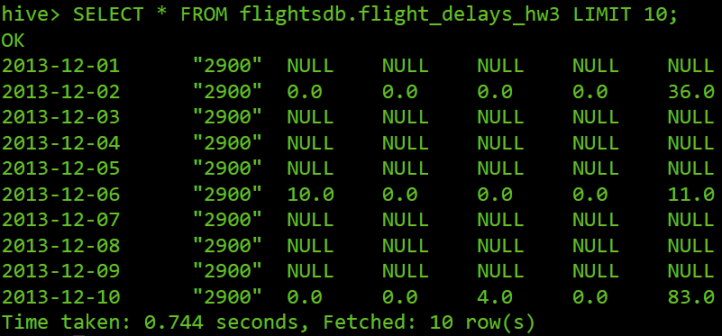

## E

[5 pts] Query the table and find out the longest delay of each category of delay. Use a meaningful alias for each column. Do this in Ambari Hive View and attach a screenshot of the results.

```
hive> SELECT
    >   max(carrier_delay) as max_carrier_delay,
    >   max(weather_delay) as max_weather_delay,
    >   max(nas_delay) as max_nas_delay,
    >   max(security_delay) as max_security_delay,
    >   max(late_aircraft_delay) as max_late_aircraft_delay
    > FROM flightsdb.flight_delays_hw3;
Query ID = root_20190330035338_722ee126-231a-4fa9-838a-072d0b4197db
Total jobs = 1
Launching Job 1 out of 1


Status: Running (Executing on YARN cluster with App id application_1553903681705_0012)

--------------------------------------------------------------------------------
        VERTICES      STATUS  TOTAL  COMPLETED  RUNNING  PENDING  FAILED  KILLED
--------------------------------------------------------------------------------
Map 1 ..........   SUCCEEDED      3          3        0        0       0       0
Reducer 2 ......   SUCCEEDED      1          1        0        0       0       0
--------------------------------------------------------------------------------
VERTICES: 02/02  [==========================>>] 100%  ELAPSED TIME: 17.40 s
--------------------------------------------------------------------------------
OK
1975.0  1451.0  1174.0  175.0   892.0
Time taken: 18.207 seconds, Fetched: 1 row(s)
```

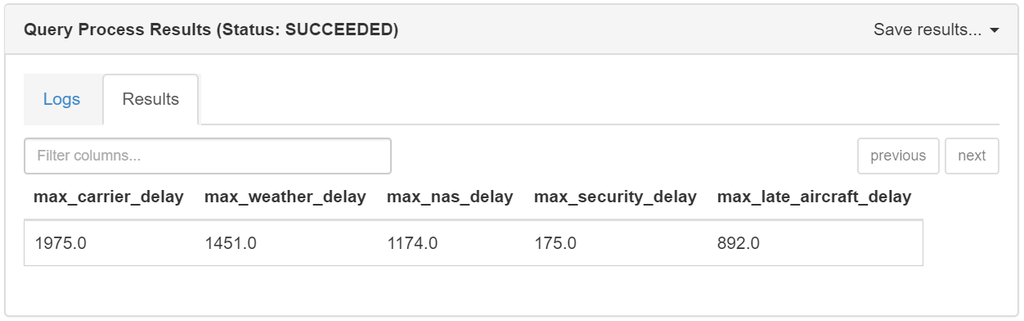